# TSF

# Overview

- concepts in ts
- descriptive analysis ts
- exponential smoothing
- ARIMA
- rstudio

# UV TSA

- Exponential Smoothing
- ARIMA
- ARCH Models

# MV TSA

- Vector Autoregressive Models
- Error Correction Models
- Cointegration

Setting up working directory

note that there are problems in running head function

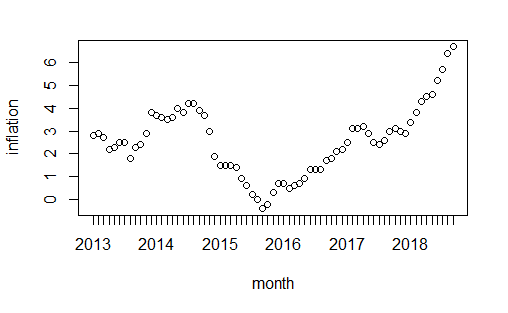

```r
inflation <- read.table("inflation.txt",header = T)
inflation$month <- gsub("M","-",inflation$month)
month <- zoo::as.yearmon(inflation$month, format="%Y-%m") #zoo package
inflation <- cbind(month,inflation["inflation"])
plot(inflation)
```

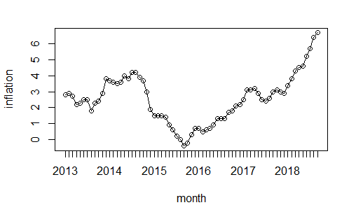

```r
plot(inflation, type="o")
```

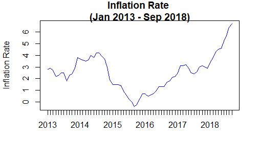

```r
plot(inflation, type="l",col="blue",xlab="",ylab="Inflation Rate",
                main="Inflation Rate \n(Jan 2013 - Sep 2018)")
```

Hodrick-Prescott Filter

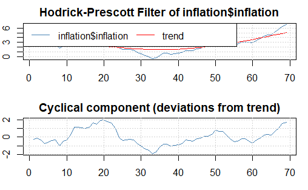

```r
inflation.hp <- mFilter::hpfilter(inflation$inflation, freq=14400, type="lambda")
plot(inflation.hp)
```

```r
inflation <- cbind(inflation,inflation.hp$trend)
colnames(inflation)[3] <- "hp_trend"
```

ggplot input: Dataframe

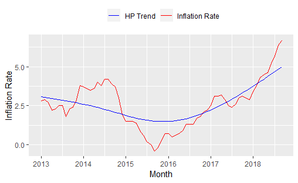

```r
library(ggplot2)
ggplot(data=inflation, aes(x=month)) +
  geom_line(aes(y=inflation, colour="Inflation Rate")) +
  geom_line(aes(y=hp_trend, colour="HP Trend")) +
  labs(x="Month", y="Inflation Rate", colour="") +
  theme(legend.position="top") +
  scale_colour_manual(values=c("blue","red"))
```

Workshop 1

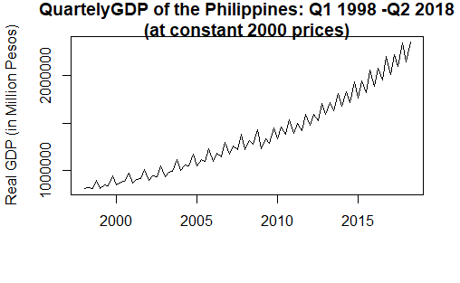

```r
rgdp.ts<-ts(read.table("rgdp2.txt",header = T),frequency=4,start=c(1998,1),end=c(2018,2))
#line plot with elements
plot(rgdp.ts, main="QuartelyGDP of the Philippines: Q1 1998 -Q2 2018
(at constant 2000 prices)",
ylab="Real GDP (in Million Pesos)", xlab="")
```

Workshop 1

```r
#time series decomposition
decomp_rgdp<-decompose(rgdp.ts,"additive")
#plot components
par(mfrow=c(2,2)) #run this par if you want a single panel of four graphs
plot(rgdp.ts,ylab="Observed",xlab="")
plot(decomp_rgdp$trend,ylab="Trend-Cycle",xlab="")
```

[figure not shown]

```r
plot(decomp_rgdp$seasonal,ylab="Seasonality",xlab="")
plot(decomp_rgdp$random,ylab="Irregular",xlab="")
```

Workshop 2

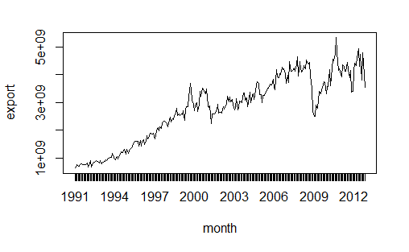

```r
export <- read.table("export.txt",header = T)
export$month <- gsub("M","-",export$month)
month <- zoo::as.yearmon(export$month, format="%Y-%m") #zoo package
export <- cbind(month,export["export"])
plot(export, type="l")
```

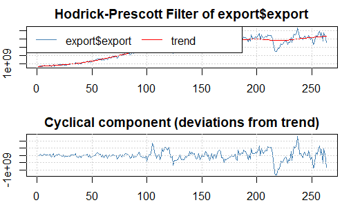

```r
export.hp <- mFilter::hpfilter(export$export, freq=14400, type="lambda")
plot(export.hp)
```

```r
export <- cbind(export,export.hp$trend)
colnames(export)[3] <- "hp_trend"
```

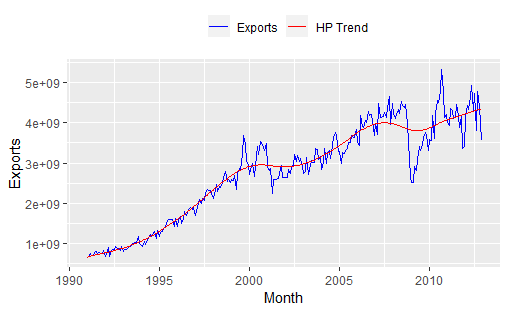

```r
library(ggplot2)
ggplot(data=export, aes(x=month)) +
  geom_line(aes(y=export, colour="Exports")) +
  geom_line(aes(y=hp_trend, colour="HP Trend")) +
  labs(x="Month", y="Exports", colour="") +
  theme(legend.position="top") +
  scale_colour_manual(values=c("blue","red"))
```

# Exponential Smoothing (no minimum requirement)

ANN - no trend no seas  
AAdN - dampened trend no seas  
AAN - w/trend no seas  
AAA - w/trend add seas  
AAM - w/trend, mult seas

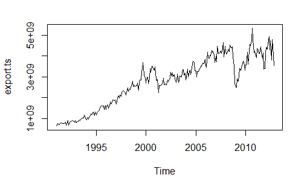

```r
export <- read.table("export.txt", header=T)
export$month <- gsub("M","-",export$month)
rtime <- zoo::as.yearmon(export$month, format="%Y-%m")
export <- cbind(rtime,export["export"])
export.ts <- ts(export$export,frequency=12,start=c(1991,1))
plot.ts(export.ts)
```

```r
library(smooth)
export.ses  <- es(export.ts,model="ANN",h=12,holdout=FALSE,intervals="parametric",level=0.95,cfType="MSE")
export.des  <- es(export.ts,model="AAdN",h=12,holdout=FALSE,intervals="parametric",level=0.95,cfType="MSE")
export.hwn  <- es(export.ts,model="AAN",h=12,holdout=FALSE,intervals="parametric",level=0.95,cfType="MSE")
export.hwa  <- es(export.ts,model="AAA",h=12,holdout=FALSE,intervals="parametric",level=0.95,cfType="MSE")
export.hwm  <- es(export.ts,model="AAM",h=12,holdout=FALSE,intervals="parametric",level=0.95,cfType="MSE")
export.auto <- es(export.ts,model="ZZZ",h=12,holdout=FALSE,intervals="parametric",level=0.95,cfType="MSE")
```

ANN means Additive errors, No trend, No seasonality (SES)  
AAdN means Additive errors, Additive (dampled) trend, No seasonality (DES)  
AAN means Additive errors, Additive trend, No seasonality (Holt-Winters no seasonality)  
AAA means Additive errors, Additive trend, Additive seasonality (HW with additive seasonality)  
AAM means Additive errors, Additive trend, Multiplicative seasonality (HW with multiplicative seasonality)  
ZZZ means all components are (Z) estimated

```r
MAPE(export.ts,export.ses$fitted)
```

```
[1] 0.064
```

```r
MAPE(export.ts,export.des$fitted)
```

```
[1] 0.063
```

```r
MAPE(export.ts,export.hwn$fitted)
```

```
[1] 0.063
```

```r
MAPE(export.ts,export.hwa$fitted)
```

```
[1] 0.055
```

```r
MAPE(export.ts,export.hwm$fitted)
```

```
[1] 0.053
```

```r
MAPE(export.ts,export.auto$fitted)
```

```
[1] 0.052
```

```r
summary(export.auto)
```

```
Time elapsed: 4.84 seconds
Model estimated: ETS(MNM)
Persistence vector g:
alpha gamma
0.659 0.000
Initial values were optimised.
16 parameters were estimated in the process
Residuals standard deviation: 0.07
Cost function type: MSE; Cost function value: 27255290365201612

Information criteria:
     AIC     AICc      BIC     BICc
10731.34 10733.55 10788.49 10794.66
95% parametric prediction intervals were constructed
```

```r
#Forecast h steps using model with lowest MAPE
forecast(export.auto,h=24)
```

```
         Point forecast Lower bound (2.5%)
Dec 2012     3714607341         3249879131
Jan 2013     3486602089         2970850405
Feb 2013     3529370187         2939965926
Mar 2013     3847770232         3141316742
Apr 2013     3565302959         2857913283
May 2013     3757312041         2961347665
Jun 2013     3883377511         3012790704
Jul 2013     3921172491         2997258904
Aug 2013     3942834664         2971695126
Sep 2013     4103179220         3051361798
Oct 2013     4026963029         2956519703
Nov 2013     3752442750         2721255291
Dec 2013     3714607341         2662059293
Jan 2014     3486602089         2470210305
Feb 2014     3529370187         2472950994
Mar 2014     3847770232         2667225196
Apr 2014     3565302959         2445751376
May 2014     3757312041         2551412799
Jun 2014     3883377511         2611040281
Jul 2014     3921172491         2611109309
Aug 2014     3942834664         2600879183
Sep 2014     4103179220         2681794447
Oct 2014     4026963029         2608321496
Nov 2014     3752442750         2409106054
         Upper bound (97.5%)
Dec 2012          4245791040
Jan 2013          4091890358
Feb 2013          4236938192
Mar 2013          4713098669
Apr 2013          4447785475
May 2013          4767219311
Jun 2013          5005532204
Jul 2013          5129885070
Aug 2013          5231339195
Sep 2013          5517562593
Oct 2013          5484973167
Nov 2013          5174386481
Dec 2013          5183320947
Jan 2014          4921198046
Feb 2014          5037080777
Mar 2014          5550838293
Apr 2014          5197333349
May 2014          5533167263
Jun 2014          5775713611
Jul 2014          5888529312
Aug 2014          5977188518
Sep 2014          6277915794
Oct 2014          6217190351
Nov 2014          5844834670
```

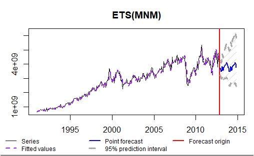

```r
plot(forecast(export.auto,h=24))
```

Workshop

```r
rgdp.ses  <- es(rgdp.ts,model="ANN",h=8,holdout=FALSE,intervals="parametric",level=0.95,cfType="MSE")
rgdp.des  <- es(rgdp.ts,model="AAdN",h=8,holdout=FALSE,intervals="parametric",level=0.95,cfType="MSE")
rgdp.hwn  <- es(rgdp.ts,model="AAN",h=8,holdout=FALSE,intervals="parametric",level=0.95,cfType="MSE")
rgdp.hwa  <- es(rgdp.ts,model="AAA",h=8,holdout=FALSE,intervals="parametric",level=0.95,cfType="MSE")
rgdp.hwm  <- es(rgdp.ts,model="AAM",h=8,holdout=FALSE,intervals="parametric",level=0.95,cfType="MSE")
rgdp.auto <- es(rgdp.ts,model="ZZZ",h=8,holdout=FALSE,intervals="parametric",level=0.95,cfType="MSE")
```

```r
MAPE(rgdp.ts,rgdp.ses$fitted)
```

```
[1] 0.05
```

```r
MAPE(rgdp.ts,rgdp.des$fitted)
```

```
[1] 0.043
```

```r
MAPE(rgdp.ts,rgdp.hwn$fitted)
```

```
[1] 0.043
```

```r
MAPE(rgdp.ts,rgdp.hwa$fitted)
```

```
[1] 0.01
```

```r
MAPE(rgdp.ts,rgdp.hwm$fitted)
```

```
[1] 0.015
```

```r
MAPE(rgdp.ts,rgdp.auto$fitted)
```

```
[1] 0.01
```

```r
#Forecast h steps using model with lowest MAPE
forecast(rgdp.auto,h=8)
```

```
        Point forecast Lower bound (2.5%)
2018 Q3        2229763            2173696
2018 Q4        2478142            2408488
2019 Q1        2281849            2208716
2019 Q2        2498461            2409157
2019 Q3        2377992            2260896
2019 Q4        2628684            2494531
2020 Q1        2434739            2291367
2020 Q2        2653737            2493374
        Upper bound (97.5%)
2018 Q3             2286377
2018 Q4             2550373
2019 Q1             2362161
2019 Q2             2594450
2019 Q3             2501387
2019 Q4             2775071
2020 Q1             2590923
2020 Q2             2832972
```

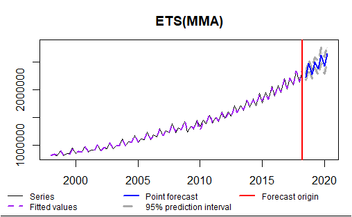

```r
plot(forecast(rgdp.auto,h=8))
```

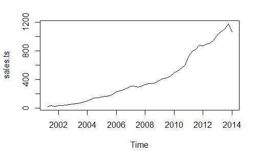

```r
sales <- read.table("sales.txt", header=T)
sales$month <- gsub("Q","-",sales$quarter)
rtime <- zoo::as.yearqtr(sales$quarter, format="%Y-%q")
sales <- cbind(rtime,sales["sales"])
sales.ts <- ts(sales$sales,frequency=4,start=c(2001,2))
plot.ts(sales.ts)
```

```r
sales.ses  <- es(sales.ts,model="ANN",h=8,holdout=FALSE,intervals="parametric",level=0.95,cfType="MSE")
sales.des  <- es(sales.ts,model="AAdN",h=8,holdout=FALSE,intervals="parametric",level=0.95,cfType="MSE")
sales.hwn  <- es(sales.ts,model="AAN",h=8,holdout=FALSE,intervals="parametric",level=0.95,cfType="MSE")
sales.hwa  <- es(sales.ts,model="AAA",h=8,holdout=FALSE,intervals="parametric",level=0.95,cfType="MSE")
sales.hwm  <- es(sales.ts,model="AAM",h=8,holdout=FALSE,intervals="parametric",level=0.95,cfType="MSE")
sales.auto <- es(sales.ts,model="ZZZ",h=8,holdout=FALSE,intervals="parametric",level=0.95,cfType="MSE")
```

```r
MAPE(sales.ts,sales.ses$fitted)
```

```
[1] 0.098
```

```r
MAPE(sales.ts,sales.des$fitted)
```

```
[1] 0.064
```

```r
MAPE(sales.ts,sales.hwn$fitted)
```

```
[1] 0.064
```

```r
MAPE(sales.ts,sales.hwa$fitted)
```

```
[1] 0.072
```

```r
MAPE(sales.ts,sales.hwm$fitted)
```

```
[1] 0.075
```

```r
MAPE(sales.ts,sales.auto$fitted)
```

```
[1] 0.07
```

```r
#Forecast h steps using model with lowest MAPE
forecast(sales.des,h=8)
```

```
        Point forecast Lower bound (2.5%)
2014 Q2       1091.315           1031.337
2014 Q3       1116.623           1027.396
2014 Q4       1141.931           1027.186
2015 Q1       1167.238           1028.363
2015 Q2       1192.544           1030.078
2015 Q3       1217.851           1031.928
2015 Q4       1243.157           1033.690
2016 Q1       1268.462           1035.231
        Upper bound (97.5%)
2014 Q2            1151.294
2014 Q3            1205.850
2014 Q4            1256.676
2015 Q1            1306.113
2015 Q2            1355.011
2015 Q3            1403.774
2015 Q4            1452.623
2016 Q1            1501.693
```

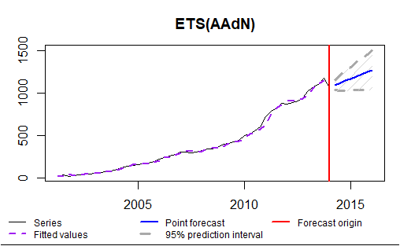

```r
plot(forecast(sales.des,h=8))
```

Day 2

ARIMA

Investigate the “dependency structure”.

- how the past values affect the present and future values.

Unit Root Test (Stationarity Tests)

- The presence of unit root makes it non-stationarity.

How to detect unit roots.

1. line graphs (suggestive)
2. Correlogram (suggestive)
3. unit root tests (conclusive)

ADF Test Setup

$H_0:$ The series has a unit root. (non stationary)  
$H_a:$ The series has no unit root. (stationary)

Load Packages

```r
library(forecast)
library(tseries)
```

```r
#Performing an ADF test on Peso-Dollar Excahange data
pder <- read.table("pder.txt", header=T)
head(pder)
```

|  | month | pder |
| --- | --- | --- |
| 1 | 1980M01 | 7.4167 |
| 2 | 1980M02 | 7.4179 |
| 3 | 1980M03 | 7.4259 |
| 4 | 1980M04 | 7.4434 |
| 5 | 1980M05 | 7.5095 |
| 6 | 1980M06 | 7.5209 |

```r
pder.ts <- ts(pder$pder,frequency=12,start=c(1980,1))
head(pder.ts)
```

```
        Jan    Feb    Mar    Apr    May    Jun
1980 7.4167 7.4179 7.4259 7.4434 7.5095 7.5209
```

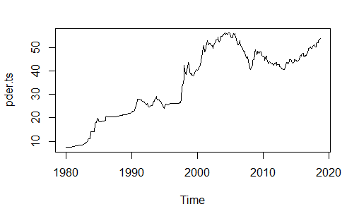

```r
plot(pder.ts)
```

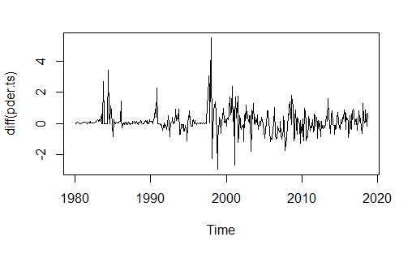

```r
plot(diff(pder.ts))
```

```r
adf.test(pder.ts, alternative="stationary")
```

```
    Augmented Dickey-Fuller Test

data:  pder.ts
Dickey-Fuller = -1.6761, Lag order = 7, p-value =
0.7149
alternative hypothesis: stationary
```

```r
adf.test(diff(pder.ts), alternative="stationary")
```

```
p-value smaller than printed p-value
```

```
    Augmented Dickey-Fuller Test

data:  diff(pder.ts)
Dickey-Fuller = -6.0099, Lag order = 7, p-value =
0.01
alternative hypothesis: stationary
```

Autocorrelation

- strength of linear correlation with it self.

Partial Autocorrelation

- removing effects.

ACF

$$Corr(y_t,y_{t+k})$$

PACF

$$Corr(y_t,y_{t-1}|y_{t-1},y_{t-2},\cdots,y_{t-k+1})$$

```r
#CPI Data
cpi <- read.table("cpi.txt", header=T)
cpi.ts <- ts(cpi$cpi,frequency=12,start=c(1994,1))
```

```r
adf.test(cpi.ts, alternative="stationary")
```

```
    Augmented Dickey-Fuller Test

data:  cpi.ts
Dickey-Fuller = -2.2918, Lag order = 6, p-value =
0.4531
alternative hypothesis: stationary
```

```r
adf.test(diff(cpi.ts), alternative="stationary")
```

```
p-value smaller than printed p-value
```

```
    Augmented Dickey-Fuller Test

data:  diff(cpi.ts)
Dickey-Fuller = -4.8423, Lag order = 6, p-value =
0.01
alternative hypothesis: stationary
```

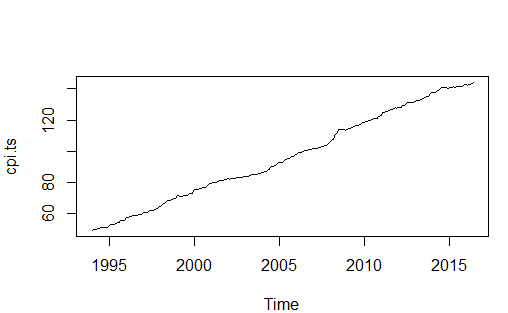

```r
par(mar = c(4, 4, 4, 1))
plot(cpi.ts)
```

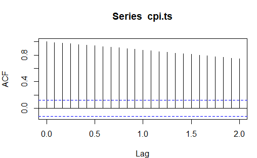

```r
acf(cpi.ts)
```

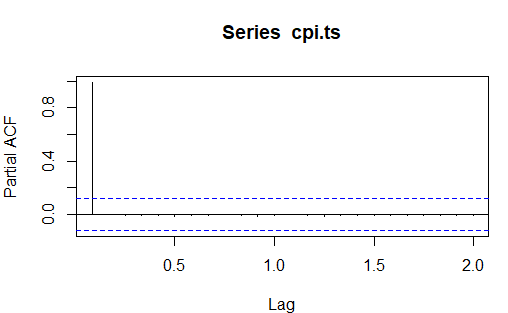

```r
pacf(cpi.ts)
```

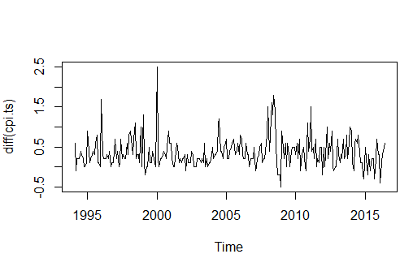

```r
par(mar = c(4, 4, 4, 1))
plot(diff(cpi.ts))
```

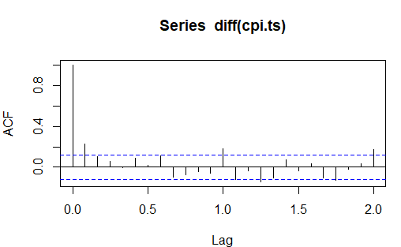

```r
acf(diff(cpi.ts))
```

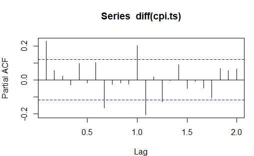

```r
pacf(diff(cpi.ts))
```

```r
#CPI Data
rain <- read.table("rain.txt", header=T)
rain.ts <- ts(rain$ave_rain,frequency=12,start=c(2009,1))
```

```r
adf.test(rain.ts, alternative="stationary")
```

```
p-value smaller than printed p-value
```

```
    Augmented Dickey-Fuller Test

data:  rain.ts
Dickey-Fuller = -4.6539, Lag order = 3, p-value =
0.01
alternative hypothesis: stationary
```

```r
adf.test(diff(rain.ts), alternative="stationary")
```

```
p-value smaller than printed p-value
```

```
    Augmented Dickey-Fuller Test

data:  diff(rain.ts)
Dickey-Fuller = -4.5946, Lag order = 3, p-value =
0.01
alternative hypothesis: stationary
```

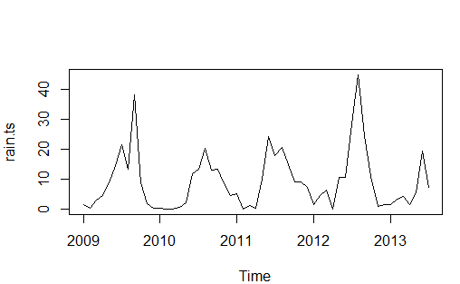

```r
par(mar = c(4, 4, 4, 1))
plot(rain.ts)
```

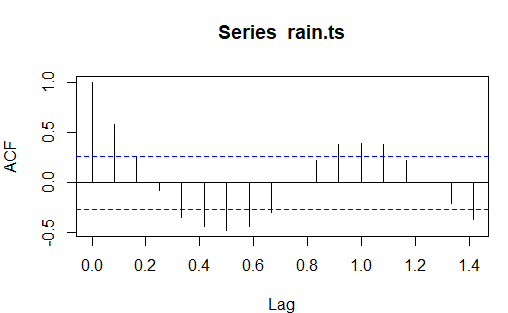

```r
acf(rain.ts)
```

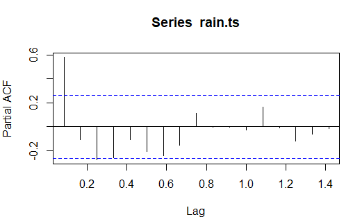

```r
pacf(rain.ts)
```

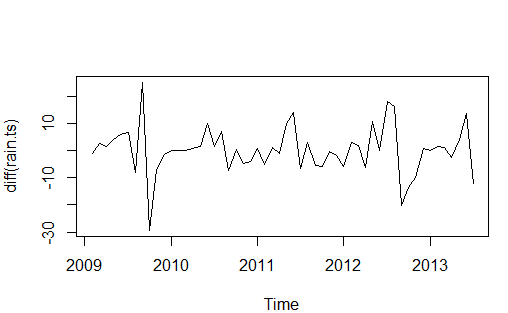

```r
par(mar = c(4, 4, 4, 1))
plot(diff(rain.ts))
```

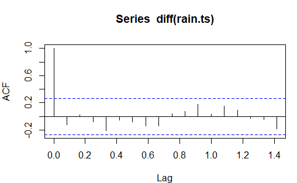

```r
acf(diff(rain.ts))
```

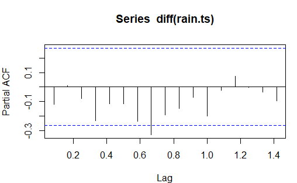

```r
pacf(diff(rain.ts))
```

Autoregressive Process

Process - Behavior

Characterizing the ts (ACF, PACF)

$AR(p)$ ACF tapers off, PACF cuts off after lag $p$

$MA(q)$ ACF cuts off after lag $q$. PACF tapers off

$ARMA(p,q)$ both ACF and PACF tapers off  
challege: know the *correct* combination of $p$ and $q$

Workshop

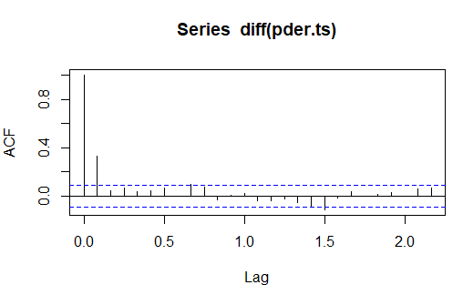

```r
par(mar = c(4, 4, 4, 1))
acf(diff(pder.ts))
```

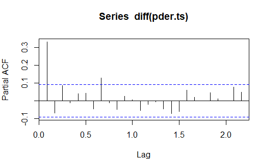

```r
pacf(diff(pder.ts))
```

$MA(1)$ since the ACF cuts off at lag 1.

$AR(1)$ since the PACF cuts off at lag 1.

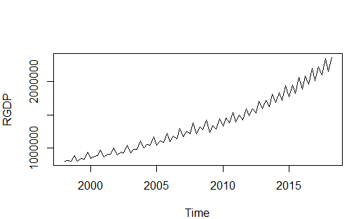

```r
par(mar = c(4, 4, 4, 1))
plot(rgdp.ts)
```

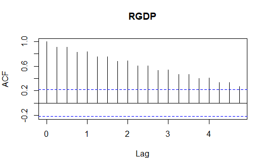

```r
acf(rgdp.ts)
```

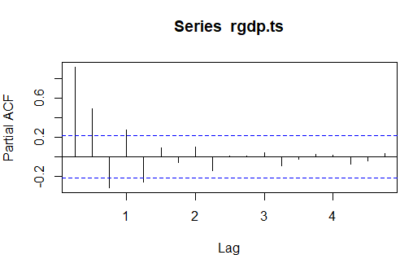

```r
pacf(rgdp.ts)
```

```r
adf.test(rgdp.ts, alternative="stationary")
```

```
p-value greater than printed p-value
```

```
    Augmented Dickey-Fuller Test

data:  rgdp.ts
Dickey-Fuller = 0.78377, Lag order = 4, p-value =
0.99
alternative hypothesis: stationary
```

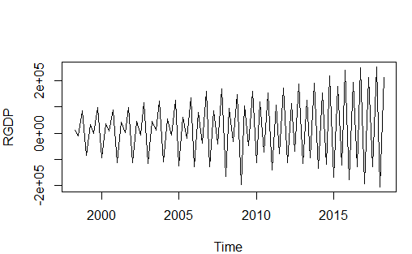

```r
par(mar = c(4, 4, 4, 1))
plot(diff(rgdp.ts,1))
```

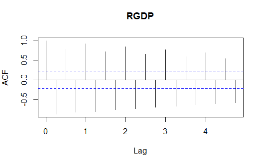

```r
acf(diff(rgdp.ts))
```

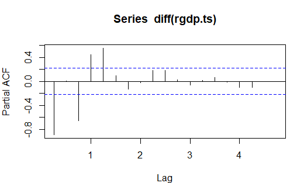

```r
pacf(diff(rgdp.ts))
```

```r
adf.test(diff(rgdp.ts), alternative="stationary")
```

```
    Augmented Dickey-Fuller Test

data:  diff(rgdp.ts)
Dickey-Fuller = -3.9881, Lag order = 4, p-value =
0.01441
alternative hypothesis: stationary
```

If there is seasonality in the data

1. Remove seasonality first and then add it later.
2. Include it in the ARIMA. If included, use SARIMA methodology.

auto.arima CAN include seasonal variations.

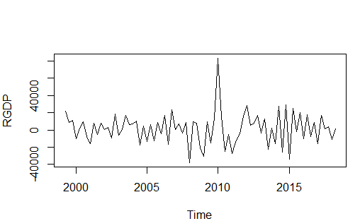

```r
# How to remove seasonality
par(mar = c(4, 4, 4, 1))
plot(diff(diff(rgdp.ts),4)) #seasonal differencing:4-qtr, 12-mos
```

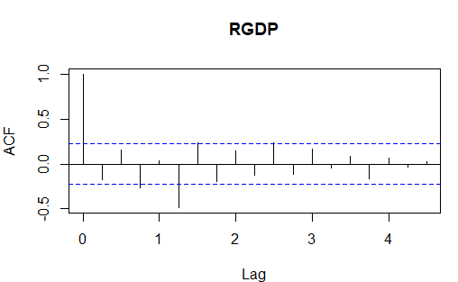

```r
acf(diff(diff(rgdp.ts),4))
```

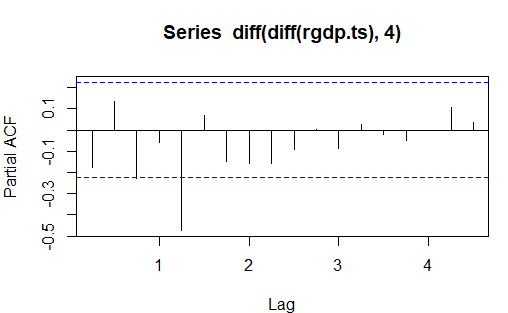

```r
pacf(diff(diff(rgdp.ts),4))
```

```r
adf.test(diff(diff(rgdp.ts),4), alternative="stationary")
```

```
p-value smaller than printed p-value
```

```
    Augmented Dickey-Fuller Test

data:  diff(diff(rgdp.ts), 4)
Dickey-Fuller = -7.1487, Lag order = 4, p-value =
0.01
alternative hypothesis: stationary
```

Forecasting

pder was differenced once

```r
pder.arima<-arima(pder.ts,order=c(1,1,0))
pder.arima
```

```
Call:
arima(x = pder.ts, order = c(1, 1, 0))

Coefficients:
         ar1
      0.3427
s.e.  0.0436

sigma^2 estimated as 0.4441:  log likelihood = -470.16,  aic = 944.31
```

```r
pder.pred<-forecast(pder.arima, h = 48, level=c(97.5))
```

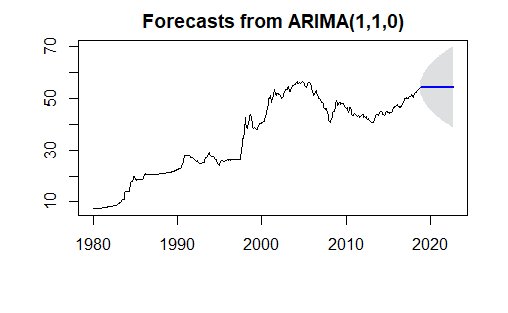

```r
plot(pder.pred)
```

```r
cpi.arima<-arima(cpi.ts,order=c(13,1,1))
cpi.arima
```

```
Call:
arima(x = cpi.ts, order = c(13, 1, 1))

Coefficients:
          ar1     ar2     ar3     ar4     ar5     ar6
      -0.1263  0.2124  0.1316  0.0585  0.0941  0.0855
s.e.   0.2094  0.0830  0.0614  0.0627  0.0607  0.0627
         ar7      ar8      ar9    ar10     ar11    ar12
      0.1626  -0.0286  -0.0501  0.0384  -0.0001  0.3072
s.e.  0.0601   0.0672   0.0648  0.0607   0.0601  0.0595
         ar13     ma1
      -0.0317  0.4881
s.e.   0.0949  0.2016

sigma^2 estimated as 0.1236:  log likelihood = -101.87,  aic = 233.74
```

```r
cpi.pred<-forecast(cpi.arima, h = 48, level=c(97.5))
```

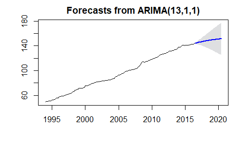

```r
plot(cpi.pred)
```

justify lag 13. why is future data dependent 13 datas back.

```r
cpi.auto.arima<-auto.arima(cpi.ts,max.order = 15)
cpi.auto.arima
```

```
Series: cpi.ts
ARIMA(1,1,0)(2,0,0)[12] with drift

Coefficients:
         ar1    sar1    sar2   drift
      0.3008  0.2319  0.1570  0.3454
s.e.  0.0597  0.0615  0.0626  0.0480

sigma^2 estimated as 0.124:  log likelihood=-99.7
AIC=209.39   AICc=209.62   BIC=227.37
```

```r
cpi.auto.pred<-forecast(cpi.auto.arima, h = 48, level=c(97.5))
```

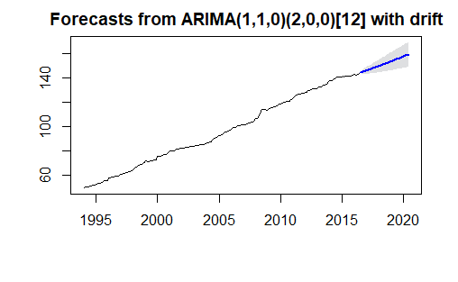

```r
plot(cpi.auto.pred)
```

```r
pder.auto.arima<-auto.arima(pder.ts,max.order= 12,trace=TRUE,seasonal=TRUE)
```

```
 Fitting models using approximations to speed things up...

 ARIMA(2,1,2)(1,0,1)[12] with drift         : 956.6925
 ARIMA(0,1,0)            with drift         : 993.655
 ARIMA(1,1,0)(1,0,0)[12] with drift         : 956.3848
 ARIMA(0,1,1)(0,0,1)[12] with drift         : 939.5997
 ARIMA(0,1,0)                               : 1000.998
 ARIMA(0,1,1)(1,0,1)[12] with drift         : 951.0263
 ARIMA(0,1,1)            with drift         : 938.289
 ARIMA(1,1,1)            with drift         : 941.2386
 ARIMA(0,1,2)            with drift         : 940.2703
 ARIMA(1,1,2)            with drift         : 941.2874
 ARIMA(0,1,1)                               : 942.0442
 ARIMA(0,1,1)(1,0,0)[12] with drift         : 951.6848

 Now re-fitting the best model(s) without approximations...

 ARIMA(0,1,1)            with drift         : 937.7384

 Best model: ARIMA(0,1,1)            with drift
```

```r
pder.auto.arima
```

```
Series: pder.ts
ARIMA(0,1,1) with drift

Coefficients:
         ma1   drift
      0.3584  0.1007
s.e.  0.0433  0.0416

sigma^2 estimated as 0.4378:  log likelihood=-465.84
AIC=937.69   AICc=937.74   BIC=950.11
```

```r
pder.auto.pred<-forecast(pder.auto.arima, h = 48, level=c(97.5))
```

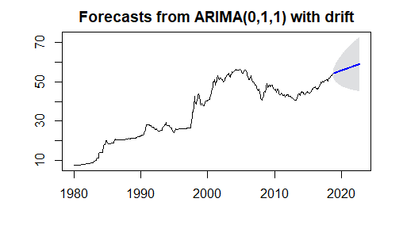

```r
plot(pder.auto.pred)
```

```r
rgdp.auto.arima<-auto.arima(rgdp.ts,max.order= 12,trace=TRUE,seasonal=TRUE)
```

```
 ARIMA(2,1,2)(1,1,1)[4]                    : Inf
 ARIMA(0,1,0)(0,1,0)[4]                    : 1728.535
 ARIMA(1,1,0)(1,1,0)[4]                    : 1729.734
 ARIMA(0,1,1)(0,1,1)[4]                    : 1730.844
 ARIMA(0,1,0)(1,1,0)[4]                    : 1730.492
 ARIMA(0,1,0)(0,1,1)[4]                    : 1730.526
 ARIMA(0,1,0)(1,1,1)[4]                    : Inf
 ARIMA(1,1,0)(0,1,0)[4]                    : 1728.479
 ARIMA(1,1,1)(0,1,0)[4]                    : Inf
 ARIMA(2,1,1)(0,1,0)[4]                    : Inf
 ARIMA(1,1,0)(0,1,1)[4]                    : 1729.989
 ARIMA(1,1,0)(1,1,1)[4]                    : 1731.858
 ARIMA(2,1,0)(0,1,0)[4]                    : 1729.06

 Best model: ARIMA(1,1,0)(0,1,0)[4]
```

```r
rgdp.auto.arima
```

```
Series: rgdp.ts
ARIMA(1,1,0)(0,1,0)[4]

Coefficients:
          ar1
      -0.1670
s.e.   0.1127

sigma^2 estimated as 315196088:  log likelihood=-862.16
AIC=1728.32   AICc=1728.48   BIC=1733
```

```r
rgdp.auto.pred<-forecast(rgdp.auto.arima, h = 48, level=c(97.5))
```

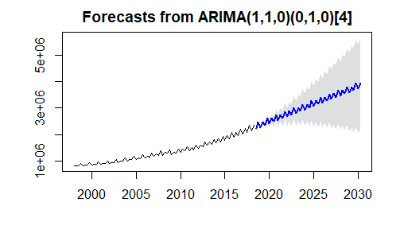

```r
plot(rgdp.auto.pred)
```

```r
export.auto.arima<-auto.arima(export.ts,max.order= 12,seasonal=TRUE, stepwise = FALSE)
export.auto.arima
```

```
Series: export.ts
ARIMA(1,1,4)(0,0,2)[12]

Coefficients:
         ar1      ma1     ma2     ma3      ma4    sma1
      0.7552  -1.1295  0.3872  0.0059  -0.1773  0.2405
s.e.  0.1216   0.1358  0.1091  0.0943   0.0649  0.0680
        sma2
      0.2742
s.e.  0.0615

sigma^2 estimated as 5.405e+16:  log likelihood=-5416.76
AIC=10849.52   AICc=10850.09   BIC=10878.07
```

```r
export.auto.pred<-forecast(export.auto.arima, h = 10, level=c(97.5))
```

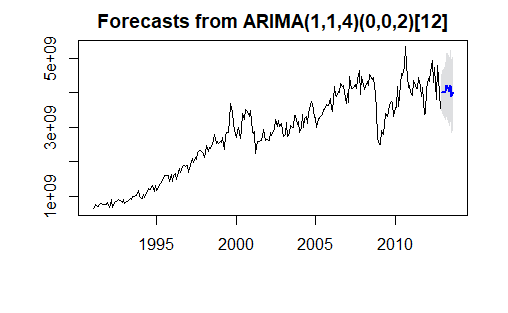

```r
plot(export.auto.pred)
```